# Predicting the Risk of Stroke in Patients Using R

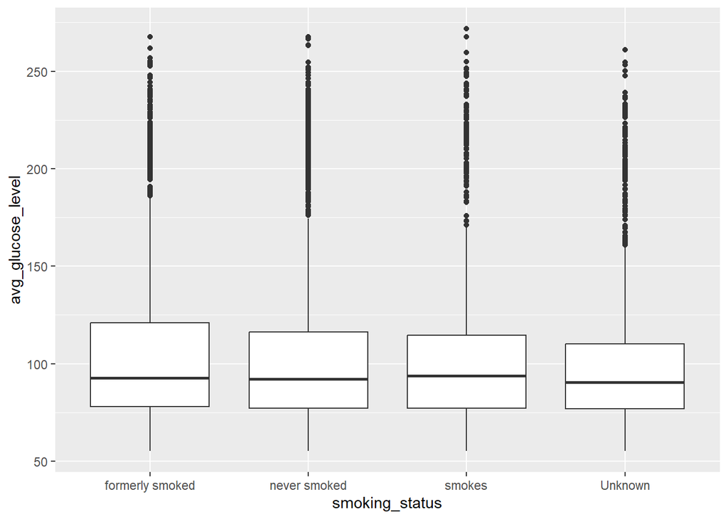

```r
q5<-df %>%
  ggplot(aes(x=smoking_status,y=avg_glucose_level,color=stroke))+geom_boxplot()
q5
```

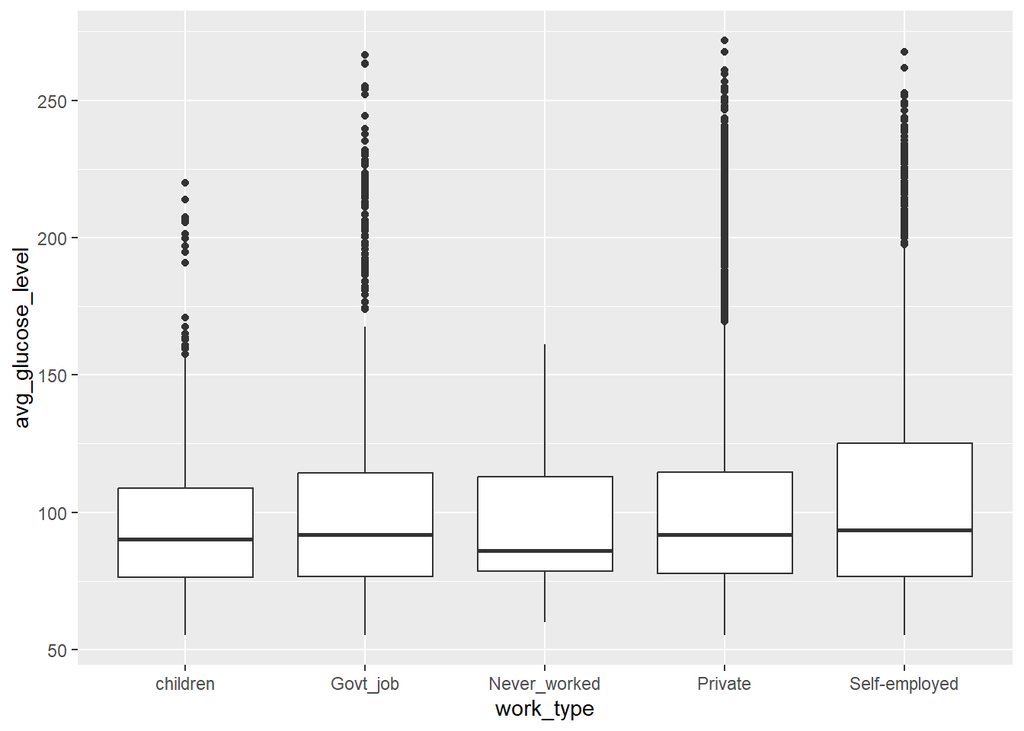

```r
q6<-df %>%
  ggplot(aes(x=work_type,y=avg_glucose_level,color=stroke))+geom_boxplot()
q6
```

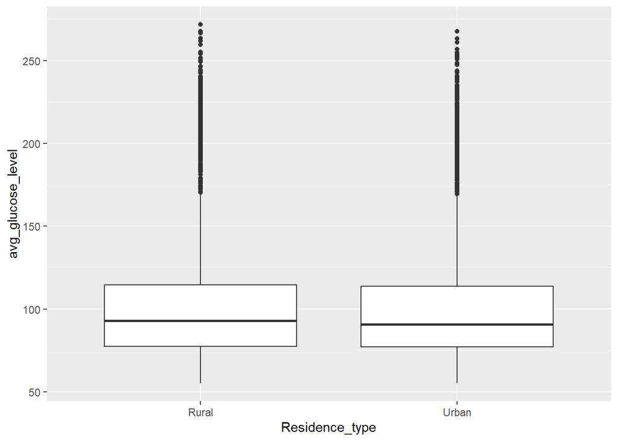

```r
q7<-df %>%
  ggplot(aes(x=Residence_type,y=avg_glucose_level,color=stroke))+geom_boxplot()
q7
```

plotting the density plot and the histogram for the continuous parameters

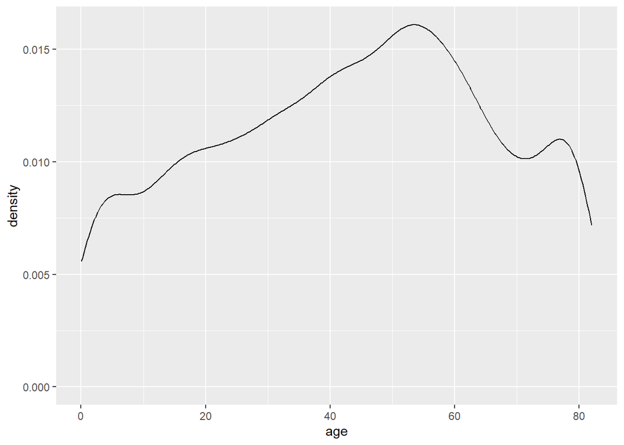

```r
e1<- ggplot(df,aes(x=age,fill=stroke))+geom_density(alpha=0.5)
e1
```

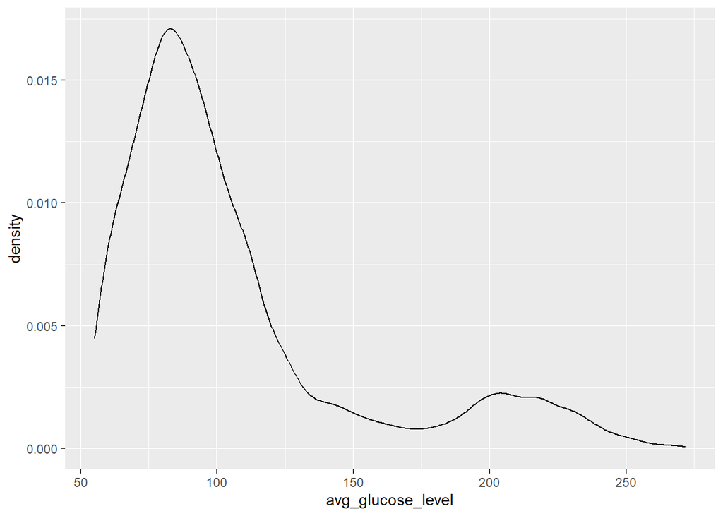

```r
e2<- ggplot(df,aes(x=avg_glucose_level,fill=stroke))+geom_density(alpha=0.5)
e2
```

[figure not shown]

```r
e3<- ggplot(df,aes(x=bmi,fill=stroke))+geom_density(alpha=0.5)
e3
```

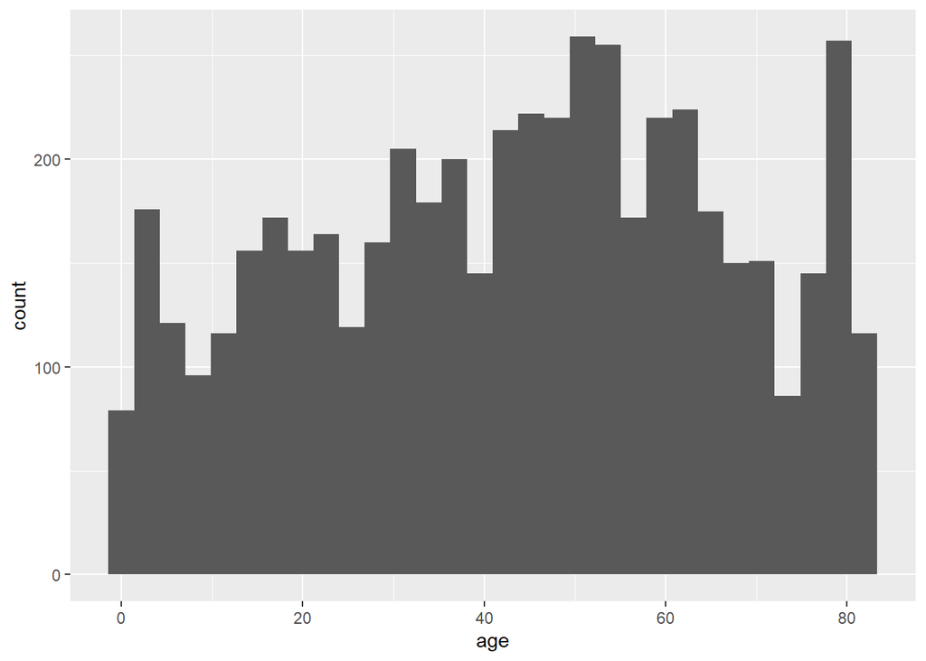

```r
e4<-ggplot(df,aes(x=age,fill=stroke))+geom_histogram()
e4
```

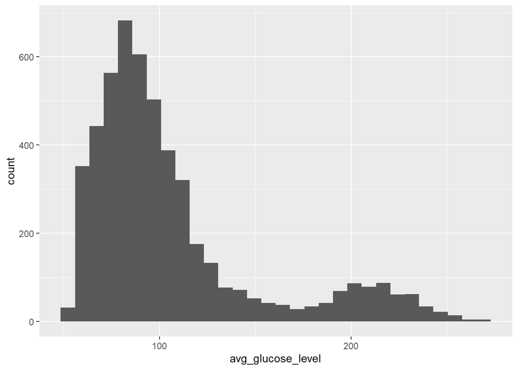

```r
e5<-ggplot(df,aes(x=avg_glucose_level,fill=stroke))+geom_histogram()
e5
```

```r
e6<-ggplot(df,aes(x=bmi,fill=stroke))+geom_histogram()
```

# Machine Learning

## Splitting the dataset

```r
set.seed(101)
```

##creating the test-train split

```r
train.index <- createDataPartition(df$stroke, p = 0.7, list = FALSE)
train.df <- df[train.index, ]
test.df <- df[-train.index, ]
```

## Checking the dimensions of the train and test dataframes

```r
dim(train.df)
```

```
## [1] 3577   11
```

```r
dim(test.df)
```

```
## [1] 1533   11
```

## Logistic Regression

```r
logistic_model <- glm(stroke ~ ., data = train.df, family = "binomial")
summary(logistic_model)
```

```
##
## Call:
## glm(formula = stroke ~ ., family = "binomial", data = train.df)
##
## Deviance Residuals:
##    Min      1Q  Median      3Q     Max
## -1.714  -0.201   0.000   0.000   3.267
##
## Coefficients:
##                              Estimate Std. Error z value Pr(>|z|)
## (Intercept)                -2.269e+01  2.923e+04  -0.001  0.99938
## genderMale                 -3.725e-03  2.076e-01  -0.018  0.98568
## age                         8.267e-02  8.524e-03   9.699  < 2e-16 ***
## hypertension                4.809e-01  2.458e-01   1.957  0.05036 .
## heart_disease              -3.470e-02  2.865e-01  -0.121  0.90361
## ever_marriedYes            -1.266e-01  3.424e-01  -0.370  0.71160
## work_typeGovt_job          -1.933e+00  9.612e-01  -2.011  0.04429 *
## work_typeNever_worked      -1.619e+01  6.178e+03  -0.003  0.99791
## work_typePrivate           -2.025e+00  9.433e-01  -2.147  0.03179 *
## work_typeSelf-employed     -2.118e+00  9.844e-01  -2.151  0.03146 *
## Residence_typeUrban         6.529e-02  1.995e-01   0.327  0.74351
## avg_glucose_level           5.108e-03  1.741e-03   2.934  0.00334 **
## bmi12.3                     6.822e-03  4.134e+04   0.000  1.00000
## bmi13.2                     5.672e-01  4.134e+04   0.000  0.99999
## bmi13.3                     6.771e-01  4.134e+04   0.000  0.99999
## bmi13.4                     1.523e-01  4.134e+04   0.000  1.00000
## bmi13.7                     3.198e-01  4.134e+04   0.000  0.99999
## bmi13.8                     3.978e-01  3.580e+04   0.000  0.99999
## bmi13.9                     6.433e-01  4.134e+04   0.000  0.99999
## bmi14                       4.000e-01  4.134e+04   0.000  0.99999
## bmi14.1                    -8.434e-01  3.160e+04   0.000  0.99998
## bmi14.2                    -1.588e+00  3.291e+04   0.000  0.99996
## bmi14.3                     1.072e-01  3.569e+04   0.000  1.00000
## bmi14.4                     3.963e-01  4.134e+04   0.000  0.99999
## bmi14.5                     4.607e-02  4.134e+04   0.000  1.00000
## bmi14.6                     4.828e-01  3.242e+04   0.000  0.99999
## bmi14.8                     5.046e-01  3.371e+04   0.000  0.99999
## bmi15                       4.627e-01  4.134e+04   0.000  0.99999
## bmi15.1                     3.893e-01  3.201e+04   0.000  0.99999
## bmi15.2                     3.451e-01  3.374e+04   0.000  0.99999
```

[output cut: 366 more lines]

```
## bmi78                       1.770e-01  4.134e+04   0.000  1.00000
## bmiN/A                      1.759e+01  2.923e+04   0.001  0.99952
## smoking_statusnever smoked -3.416e-01  2.476e-01  -1.380  0.16770
## smoking_statussmokes        1.640e-01  3.096e-01   0.530  0.59629
## smoking_statusUnknown      -1.563e-01  2.989e-01  -0.523  0.60117
## ---
## Signif. codes:  0 '***' 0.001 '**' 0.01 '*' 0.05 '.' 0.1 ' ' 1
##
## (Dispersion parameter for binomial family taken to be 1)
##
##     Null deviance: 1397.42  on 3576  degrees of freedom
## Residual deviance:  812.91  on 3176  degrees of freedom
## AIC: 1614.9
##
## Number of Fisher Scoring iterations: 20
```

# Conclusion

## EDA Conclusion

The exploratory data analysis (EDA) of the stroke prediction dataset revealed several key insights about the data. First, the data is imbalanced, with only 4.87% of the observations representing patients who have had a stroke. This imbalance may impact the accuracy of the predictive models we build, as there may be insufficient data for the minority class (stroke patients) to accurately predict the likelihood of a stroke occurring.

## Overall Conclusion

In conclusion, the analysis of the stroke dataset through exploration, visualization, and statistical analysis has provided a better understanding of the factors that may be associated with an increased risk of stroke. By identifying these factors and understanding their relationships with the risk of stroke, healthcare professionals can potentially develop strategies for preventing or mitigating this serious health condition. The EDA has also revealed some imbalances in the data, such as a higher proportion of male patients and a higher prevalence of hypertension, which will need to be taken into consideration when building predictive models. Additionally, the presence of missing values in some variables will need to be addressed in order to improve the accuracy of the models.

# References

1. Letham, B., Rudin, C., McCormick, T. H., & Madigan, D. (2015). Interpretable classifiers using rules and bayesian analysis: Building a better stroke prediction model. The Annals of Applied Statistics, 9(3), 1350-1371.
2. Moulton, E., Magno, S., Valabregue, R., Amor-Sahli, M., Pires, C., Lehéricy, S., … & Rosso, C. (2019). Acute diffusivity biomarkers for motor and language outcome prediction in mild-to-severe stroke patients. Stroke, 50(8), 2050-2056.